# Eric_Hirsch_624_Homework_4

2023-02-24

*3.1. The UC Irvine Machine Learning Repository contains a data set related to glass identification.*

*3.1a (a) Using visualizations, explore the predictor variables to understand their distributions as well as the relationships between predictors.*

```
##        RI              Na              Mg              Al
##  Min.   :1.511   Min.   :10.73   Min.   :0.000   Min.   :0.290
##  1st Qu.:1.517   1st Qu.:12.91   1st Qu.:2.115   1st Qu.:1.190
##  Median :1.518   Median :13.30   Median :3.480   Median :1.360
##  Mean   :1.518   Mean   :13.41   Mean   :2.685   Mean   :1.445
##  3rd Qu.:1.519   3rd Qu.:13.82   3rd Qu.:3.600   3rd Qu.:1.630
##  Max.   :1.534   Max.   :17.38   Max.   :4.490   Max.   :3.500
##        Si              K                Ca               Ba
##  Min.   :69.81   Min.   :0.0000   Min.   : 5.430   Min.   :0.000
##  1st Qu.:72.28   1st Qu.:0.1225   1st Qu.: 8.240   1st Qu.:0.000
##  Median :72.79   Median :0.5550   Median : 8.600   Median :0.000
##  Mean   :72.65   Mean   :0.4971   Mean   : 8.957   Mean   :0.175
##  3rd Qu.:73.09   3rd Qu.:0.6100   3rd Qu.: 9.172   3rd Qu.:0.000
##  Max.   :75.41   Max.   :6.2100   Max.   :16.190   Max.   :3.150
##        Fe          Type
##  Min.   :0.00000   1:70
##  1st Qu.:0.00000   2:76
##  Median :0.00000   3:17
##  Mean   :0.05701   5:13
##  3rd Qu.:0.10000   6: 9
##  Max.   :0.51000   7:29
```

```
## 'data.frame':    214 obs. of  10 variables:
##  $ RI  : num  1.52 1.52 1.52 1.52 1.52 ...
##  $ Na  : num  13.6 13.9 13.5 13.2 13.3 ...
##  $ Mg  : num  4.49 3.6 3.55 3.69 3.62 3.61 3.6 3.61 3.58 3.6 ...
##  $ Al  : num  1.1 1.36 1.54 1.29 1.24 1.62 1.14 1.05 1.37 1.36 ...
##  $ Si  : num  71.8 72.7 73 72.6 73.1 ...
##  $ K   : num  0.06 0.48 0.39 0.57 0.55 0.64 0.58 0.57 0.56 0.57 ...
##  $ Ca  : num  8.75 7.83 7.78 8.22 8.07 8.07 8.17 8.24 8.3 8.4 ...
##  $ Ba  : num  0 0 0 0 0 0 0 0 0 0 ...
##  $ Fe  : num  0 0 0 0 0 0.26 0 0 0 0.11 ...
##  $ Type: Factor w/ 6 levels "1","2","3","5",..: 1 1 1 1 1 1 1 1 1 1 ...
```

The heatmap shows some multicollinearity. However, the RI/CA and MG/Type pairs are the only ones with a correlation (absolut value) above .6.

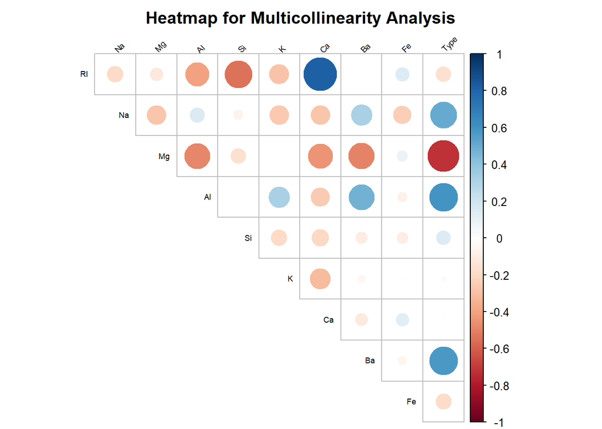

```
##   col1 col2 correlation
## 1   RI   Ca   0.8104027
## 2   Mg Type  -0.7281595
```

*3.1b Do there appear to be any outliers in the data? Are any predictors skewed?*

Boxplots show possible outliers for K, Fe, Na and possibly others. Without knowing more about the data we cannot know whether they are anomalies or data errors. Distributions vary - some are relative normal while others (K, Ba, Fe, Mg) are highly skewed or are bimodal.

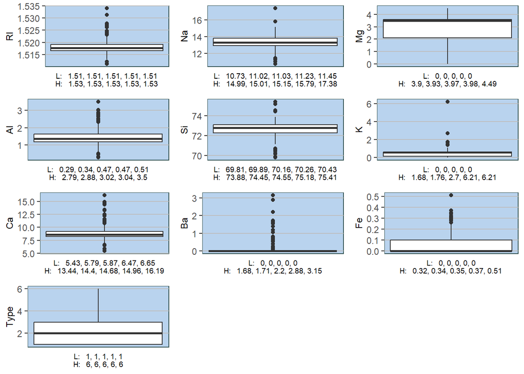

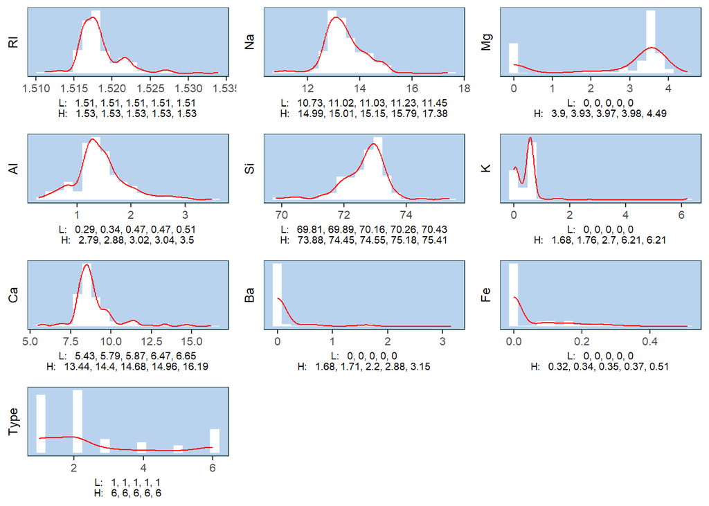

*3.1c (c) Are there any relevant transformations of one or more predictors that might improve the classification model?*

We can run a multinomial regression to get a baseline. The AIC is 399.

```
## Call:
## multinom(formula = Type ~ ., data = dfGlass)
##
## Coefficients:
##   (Intercept)        RI         Na          Mg         Al         Si
## 2   114.01139 210.99092 -3.5715880 -6.14888398 -0.0777839 -4.4509190
## 3    46.69565 -61.97027  1.6471464 -0.01788714  2.5121161  0.2207149
## 4    19.54782  14.22700 -0.4893655 -3.69586811 10.1611011 -0.5204113
## 5   -14.59763 -21.52840 10.7663636 -7.48120815 34.9748591 -0.9212133
## 6   -33.83528  22.99089  2.4341715 -5.00880431  6.2849258 -0.1495441
##               K         Ca          Ba           Fe
## 2   -3.70543961 -4.6895169   -5.757871    2.2610525
## 3   -0.67459086  0.6082768   -2.208131    1.5301451
## 4    0.62817476 -0.4292740   -3.450644   -0.6424633
## 5 -197.82120395 -4.7069924 -149.906448 -407.9088594
## 6   -0.06454676 -2.2076868   -2.475847  -15.9357312
##
## Residual Deviance: 299.4877
## AIC: 399.4877
```

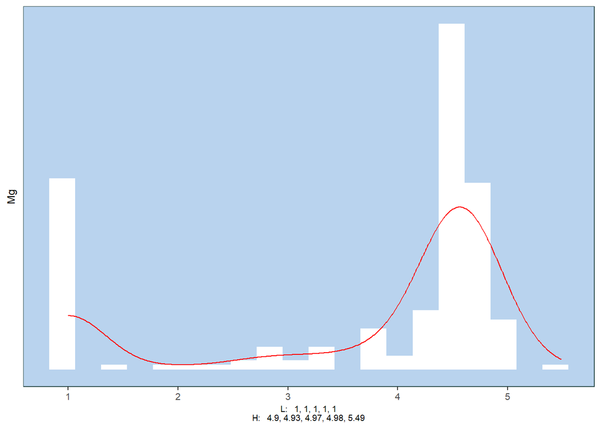

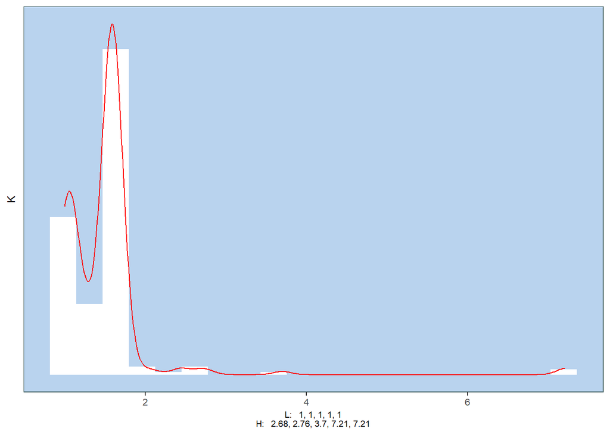

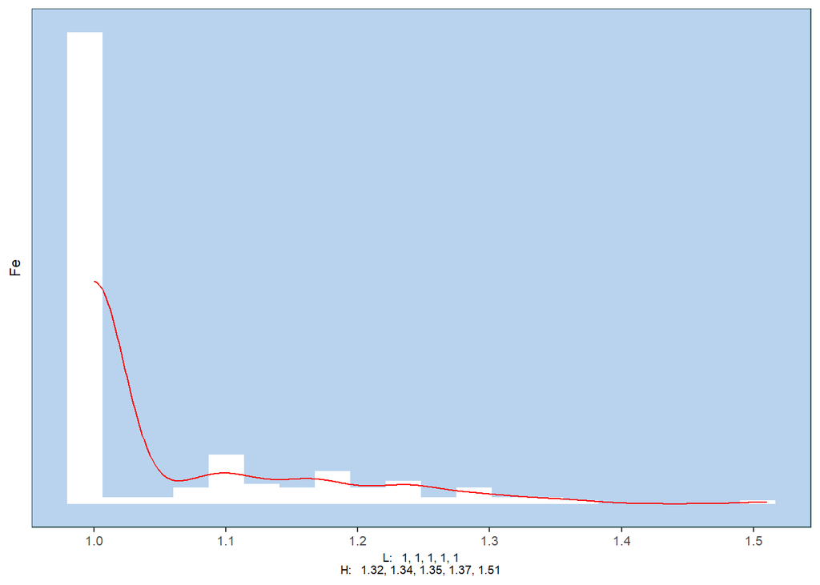

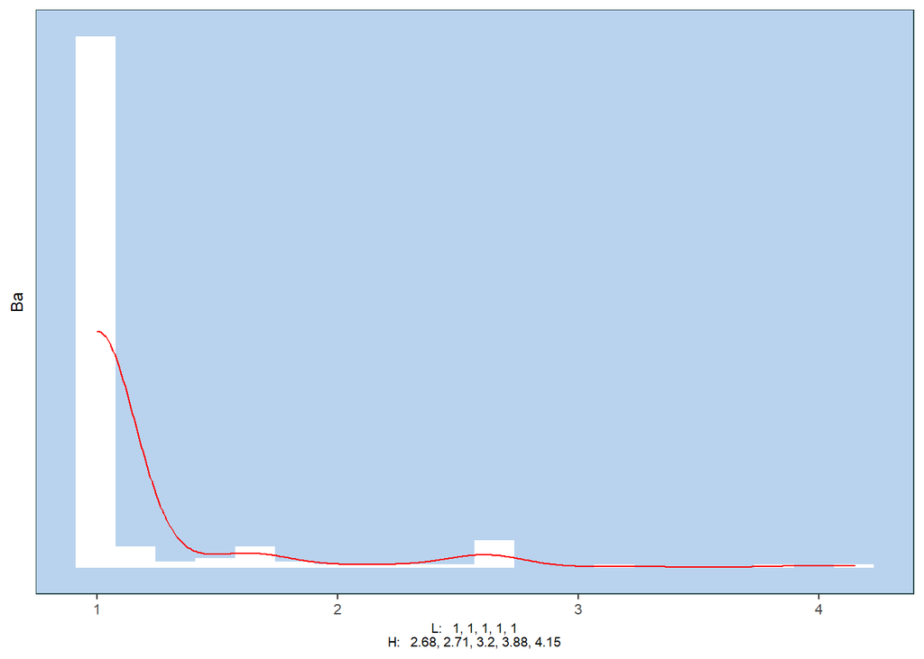

```
## Call:
## multinom(formula = Type ~ ., data = Z3)
##
## Coefficients:
##   (Intercept)        RI         Na         Mg          Al          Si
## 2   113.94456 211.81767 -3.4500622 -6.0623633  0.05647234 -4.33290475
## 3    46.89297 -66.39542  1.7744817 -0.0176589  2.57340672  0.28778787
## 4    19.56783  13.51478 -0.4072638 -3.6513253 10.21867003 -0.44189454
## 5   -13.55207 -19.87161 17.4342477 -0.9194476 37.86067550  7.17098886
## 6   -33.47140  26.40007  2.6195326 -4.8354032  6.45292482  0.04886831
##              K          Ca          Ba           Fe
## 2   -3.6566716 -4.59361444   -5.553624    2.5592169
## 3   -0.5533918  0.66109882   -2.065010    1.9890390
## 4    0.5222810 -0.38147922   -3.290036    0.0784358
## 5 -192.8933449  0.07765026 -146.291051 -411.5641617
## 6   -0.1074083 -2.07303782   -2.227164  -17.0919084
##
## Residual Deviance: 299.407
## AIC: 399.407
```

Removing possible outliers reduces our AIC to .384. We should take care in removing this data, which might tell us something interesting when data meets certain rare conditions.

```
## Call:
## multinom(formula = Type ~ ., data = dfGlass2)
##
## Coefficients:
##   (Intercept)        RI        Na         Mg         Al         Si            K
## 2   122.84311 215.34004 -3.432588 -22.947517 -0.2434202 -4.4533505   -4.7581457
## 3    14.64205 -43.75449  1.752566   1.219765  2.2603289  0.2577828   -0.4274166
## 4   -23.08481 -45.60621  1.109521 -14.160322  9.5549059  0.9326723    7.9263504
## 5   -16.26290 -26.67097 10.067977 -19.347767 22.0682116 -1.0313899 -111.5089247
## 6   -29.35202 -13.28671  2.962144 -18.392960  5.5610507  0.4778259    5.1401922
##           Ca          Ba          Fe
## 2 -5.1541081  -8.7702794    3.248957
## 3  0.4396209  -7.0128419    2.195144
## 4  0.9594574   0.6742615   -9.558496
## 5 -0.4318646 -99.5575514 -142.824377
## 6 -1.4674478   0.3171998  -21.231991
##
## Residual Deviance: 283.9312
## AIC: 383.9312
```

```
##                  Class          date     plant.stand  precip      temp
##  brown-spot         : 92   5      :149   0   :354    0   : 74   0   : 80
##  alternarialeaf-spot: 91   4      :131   1   :293    1   :112   1   :374
##  frog-eye-leaf-spot : 91   3      :118   NA's: 36    2   :459   2   :199
##  phytophthora-rot   : 88   2      : 93               NA's: 38   NA's: 30
##  anthracnose        : 44   6      : 90
##  brown-stem-rot     : 44   (Other):101
##  (Other)            :233   NA's   :  1
##    hail     crop.hist  area.dam    sever     seed.tmt     germ     plant.growth
##  0   :435   0   : 65   0   :123   0   :195   0   :305   0   :165   0   :441
##  1   :127   1   :165   1   :227   1   :322   1   :222   1   :213   1   :226
##  NA's:121   2   :219   2   :145   2   : 45   2   : 35   2   :193   NA's: 16
##             3   :218   3   :187   NA's:121   NA's:121   NA's:112
##             NA's: 16   NA's:  1
##
##
##  leaves  leaf.halo  leaf.marg  leaf.size  leaf.shread leaf.malf  leaf.mild
##  0: 77   0   :221   0   :357   0   : 51   0   :487    0   :554   0   :535
##  1:606   1   : 36   1   : 21   1   :327   1   : 96    1   : 45   1   : 20
##          2   :342   2   :221   2   :221   NA's:100    NA's: 84   2   : 20
##          NA's: 84   NA's: 84   NA's: 84                          NA's:108
##
##
##
##    stem     lodging    stem.cankers canker.lesion fruiting.bodies ext.decay
##  0   :296   0   :520   0   :379     0   :320      0   :473        0   :497
##  1   :371   1   : 42   1   : 39     1   : 83      1   :104        1   :135
##  NA's: 16   NA's:121   2   : 36     2   :177      NA's:106        2   : 13
##                        3   :191     3   : 65                      NA's: 38
##                        NA's: 38     NA's: 38
##
##
##  mycelium   int.discolor sclerotia  fruit.pods fruit.spots   seed
##  0   :639   0   :581     0   :625   0   :407   0   :345    0   :476
##  1   :  6   1   : 44     1   : 20   1   :130   1   : 75    1   :115
##  NA's: 38   2   : 20     NA's: 38   2   : 14   2   : 57    NA's: 92
##             NA's: 38                3   : 48   4   :100
##                                     NA's: 84   NA's:106
##
##
##  mold.growth seed.discolor seed.size  shriveling  roots
##  0   :524    0   :513      0   :532   0   :539   0   :551
##  1   : 67    1   : 64      1   : 59   1   : 38   1   : 86
##  NA's: 92    NA's:106      NA's: 92   NA's:106   2   : 15
##                                                  NA's: 31
##
##
##
```

```
## 'data.frame':    683 obs. of  36 variables:
##  $ Class          : Factor w/ 19 levels "2-4-d-injury",..: 11 11 11 11 11 11 11 11 11 11 ...
##  $ date           : Factor w/ 7 levels "0","1","2","3",..: 7 5 4 4 7 6 6 5 7 5 ...
##  $ plant.stand    : Ord.factor w/ 2 levels "0"<"1": 1 1 1 1 1 1 1 1 1 1 ...
##  $ precip         : Ord.factor w/ 3 levels "0"<"1"<"2": 3 3 3 3 3 3 3 3 3 3 ...
##  $ temp           : Ord.factor w/ 3 levels "0"<"1"<"2": 2 2 2 2 2 2 2 2 2 2 ...
##  $ hail           : Factor w/ 2 levels "0","1": 1 1 1 1 1 1 1 2 1 1 ...
##  $ crop.hist      : Factor w/ 4 levels "0","1","2","3": 2 3 2 2 3 4 3 2 4 3 ...
##  $ area.dam       : Factor w/ 4 levels "0","1","2","3": 2 1 1 1 1 1 1 1 1 1 ...
##  $ sever          : Factor w/ 3 levels "0","1","2": 2 3 3 3 2 2 2 2 2 3 ...
##  $ seed.tmt       : Factor w/ 3 levels "0","1","2": 1 2 2 1 1 1 2 1 2 1 ...
##  $ germ           : Ord.factor w/ 3 levels "0"<"1"<"2": 1 2 3 2 3 2 1 3 2 3 ...
##  $ plant.growth   : Factor w/ 2 levels "0","1": 2 2 2 2 2 2 2 2 2 2 ...
##  $ leaves         : Factor w/ 2 levels "0","1": 2 2 2 2 2 2 2 2 2 2 ...
##  $ leaf.halo      : Factor w/ 3 levels "0","1","2": 1 1 1 1 1 1 1 1 1 1 ...
```

[output cut: 22 more lines]

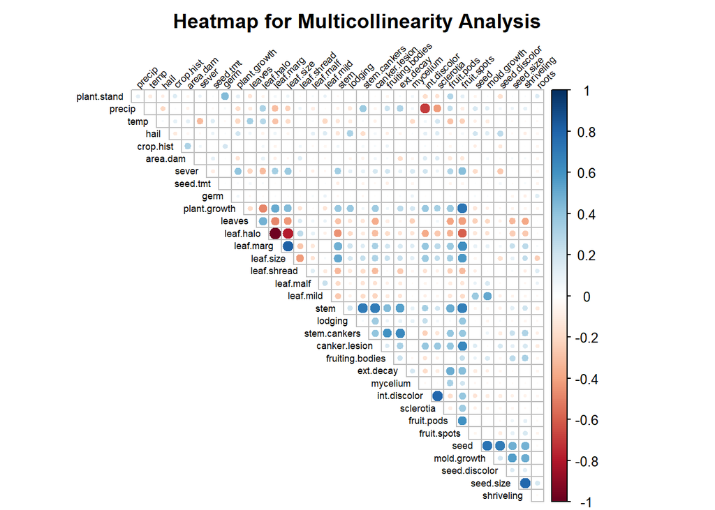

```
##            col1         col2 correlation
## 1  plant.growth  fruit.spots   0.7282393
## 2     leaf.halo    leaf.marg  -0.9751832
## 3     leaf.halo    leaf.size  -0.7832016
## 5     leaf.marg    leaf.size   0.8194296
## 8          stem stem.cankers   0.7025111
## 10 int.discolor    sclerotia   0.7982714
## 13         seed  mold.growth   0.7361260
## 15    seed.size   shriveling   0.7899825
```

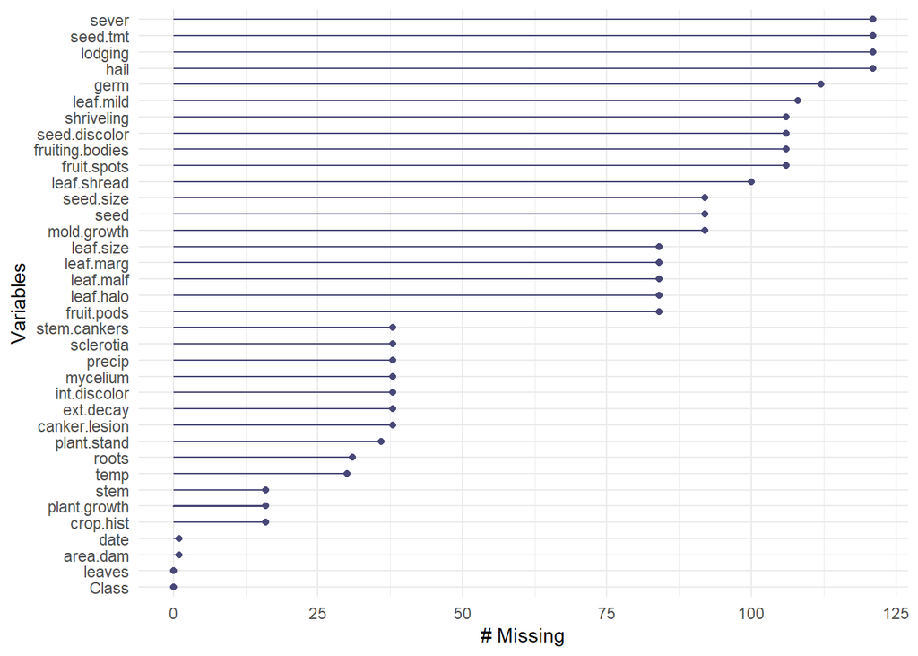

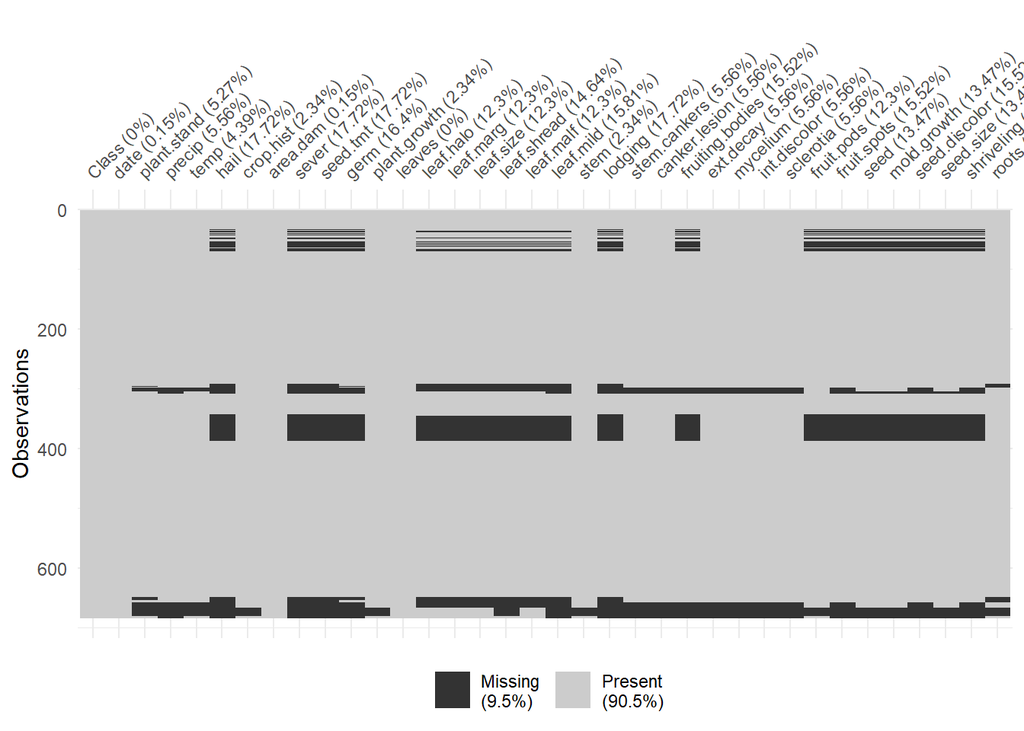

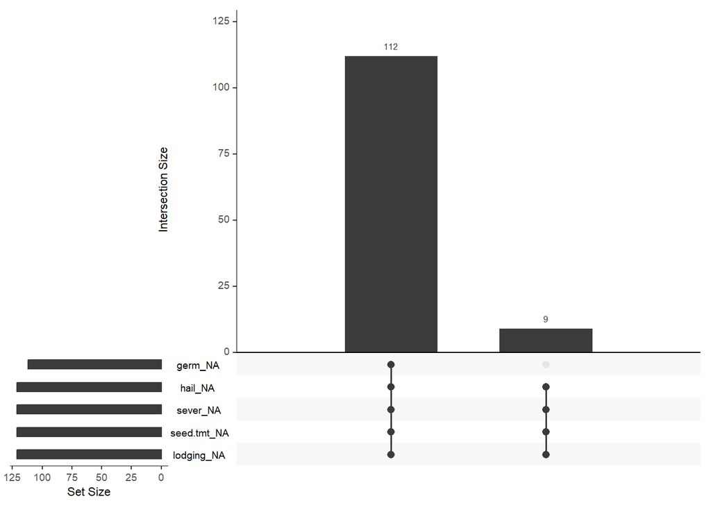